# Module 92

#### Hemi-module gene counts:

155 probesets in hemi-module A.  
164 probesets in hemi-module B.  
Note: While the mapping of probesets to genes is usually one-to-one, some genes are targeted by multiple probesets, some probesets target multiple genes, and some probesets do not target any genes (i.e., the region of the genome they match is no longer considered genic).

#### Contrast SVE:

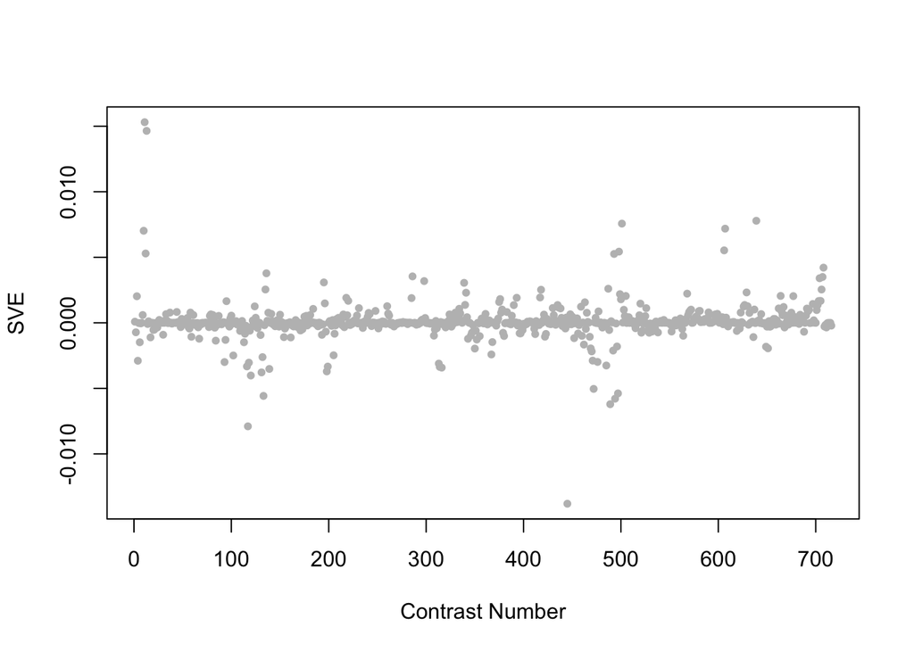

Positive SVE Contrasts:

|  | Contrast.Num | SVE | GEO.GSE | Cond.1 | Cond.2 | Mutation |
| --- | --- | --- | --- | --- | --- | --- |
| GSE9682.s2t1.vs.s0t1 | 11 | 0.02 | GSE9682 | N2-Cel-TORRNAi-fasting-biological rep1 | N2-controlRNAi-fasting-biological rep1 | TOR |
| GSE9682.s2t2.vs.s0t2 | 13 | 0.01 | GSE9682 | N2-Cel-TORRNAi-fed-biological rep1 | N2-controlRNAi-fed-biological rep1 | TOR |
| GSE18132.s1t1.vs.s0t1 | 639 | 0.01 | GSE18132 | Ogt starved L1, biological replicate 1 | WT Starved L1, biological rep1 | ogt-1 |
| GSE23013.s1t1.vs.s0t1 | 501 | 0.01 | GSE23013 | young adult_24hr Toluene exposure_rep1 | young adult_not exposed_rep1 |  |
| GSE21784.s1t1.vs.s2t1 | 607 | 0.01 | GSE21784 | L4 larvae, biological rep1 | day 6 adults, biological rep 1 |  |

Negative SVE Contrasts:

|  | Contrast.Num | SVE | GEO.GSE | Cond.1 | Cond.2 | Mutation |
| --- | --- | --- | --- | --- | --- | --- |
| GSE27677B.s0t9.vs.s0t7 | 445 | -0.01 | GSE27677 | N2, Fed 48 h, rep 1 | N2, Fed 24 h, rep 1 |  |
| GSE54024.s3t1.vs.s6t1 | 117 | -0.01 | GSE54024 | nuo-6(qm200) young adults, biological rep 1 | isp-1(qm150) ced-4(n1162) double mutant young adults, biological rep 1 |  |
| GSE23528B.s1t3.vs.s1t1 | 489 | -0.01 | GSE23528 | Adult at T34 in CC, time-series experiment 3 | Adult at T26 in CC, time-series experiment 3 |  |
| GSE23528C.s1t3.vs.s1t1 | 494 | -0.01 | GSE23528 | Adult at T34 in DD, time-series experiment 2 | Adult at T26 in DD, time-series experiment 2 |  |
| GSE52064.s2t1.vs.s4t1 | 133 | -0.01 | GSE52064 | mes-4_1 | lin-54;mes-4_1 | lin-54 |

$~$

#### Contrast SVE, Up-Regulated Genes Only:

Calculating SVE for up-regulated and down-regulated genes separately may be more informative in many cases than projecting the up- and down- gene sets together. This is due to the fact that the weight distribution of many modules is highly skewed, indicating that only one of the hemi-modules may be biologically meaningful (i.e., a set of genes are strongly correlated by only a few genes (or none) are strongly anti-correlated to that set.)

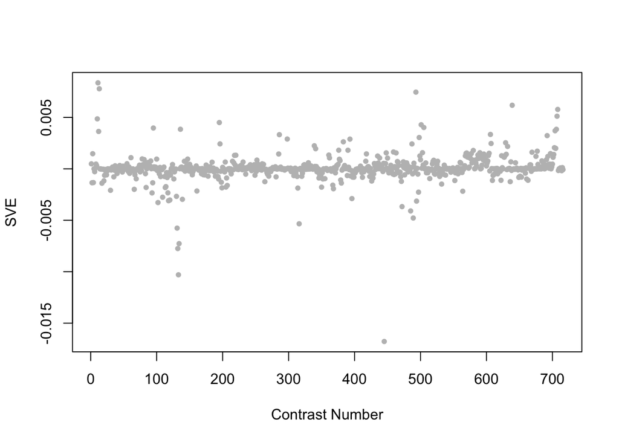

Positive SVE Contrasts:

|  | Contrast.Num | SVE | GEO.GSE | Cond.1 | Cond.2 | Mutation |
| --- | --- | --- | --- | --- | --- | --- |
| GSE9682.s2t1.vs.s0t1 | 11 | 0.01 | GSE9682 | N2-Cel-TORRNAi-fasting-biological rep1 | N2-controlRNAi-fasting-biological rep1 | TOR |
| GSE9682.s2t2.vs.s0t2 | 13 | 0.01 | GSE9682 | N2-Cel-TORRNAi-fed-biological rep1 | N2-controlRNAi-fed-biological rep1 | TOR |
| GSE23528C.s1t2.vs.s1t1 | 493 | 0.01 | GSE23528 | Adult at T30 in DD, time-series experiment 2 | Adult at T26 in DD, time-series experiment 2 |  |
| GSE18132.s1t1.vs.s0t1 | 639 | 0.01 | GSE18132 | Ogt starved L1, biological replicate 1 | WT Starved L1, biological rep1 | ogt-1 |
| GSE11055.s1t8.vs.s1t1 | 708 | 0.01 | GSE11055 | L2 larvae 24 hr after hatching in the presence of food | embryo 2 hr before hatching |  |

Negative SVE Contrasts:

|  | Contrast.Num | SVE | GEO.GSE | Cond.1 | Cond.2 | Mutation |
| --- | --- | --- | --- | --- | --- | --- |
| GSE27677B.s0t9.vs.s0t7 | 445 | -0.02 | GSE27677 | N2, Fed 48 h, rep 1 | N2, Fed 24 h, rep 1 |  |
| GSE52064.s2t1.vs.s4t1 | 133 | -0.01 | GSE52064 | mes-4_1 | lin-54;mes-4_1 | lin-54 |
| GSE52064.s1t1.vs.s3t1 | 132 | -0.01 | GSE52064 | wildtype_1 | lin-54_1 | lin-54 |
| GSE52064.s1t1.vs.s4t1 | 134 | -0.01 | GSE52064 | wildtype_1 | lin-54;mes-4_1 | lin-54;mes-4 |
| GSE52064.s2t1.vs.s3t1 | 131 | -0.01 | GSE52064 | mes-4_1 | lin-54_1 | mes-4 vs. lin-54 |

$~$

#### Contrast SVE, Down-Regulated Genes Only:

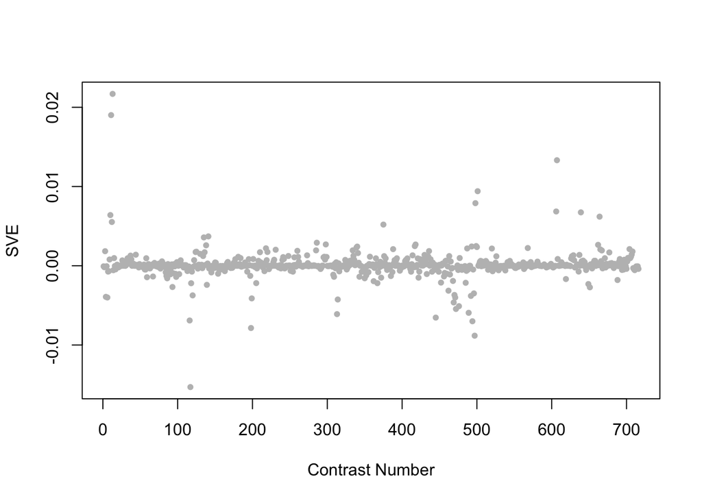

Positive SVE Contrasts:

|  | Contrast.Num | SVE | GEO.GSE | Cond.1 | Cond.2 | Mutation |
| --- | --- | --- | --- | --- | --- | --- |
| GSE9682.s2t2.vs.s0t2 | 13 | 0.02 | GSE9682 | N2-Cel-TORRNAi-fed-biological rep1 | N2-controlRNAi-fed-biological rep1 | TOR |
| GSE9682.s2t1.vs.s0t1 | 11 | 0.02 | GSE9682 | N2-Cel-TORRNAi-fasting-biological rep1 | N2-controlRNAi-fasting-biological rep1 | TOR |
| GSE21784.s1t1.vs.s2t1 | 607 | 0.01 | GSE21784 | L4 larvae, biological rep1 | day 6 adults, biological rep 1 |  |
| GSE23013.s1t1.vs.s0t1 | 501 | 0.01 | GSE23013 | young adult_24hr Toluene exposure_rep1 | young adult_not exposed_rep1 |  |
| GSE23013.s4t1.vs.s0t1 | 498 | 0.01 | GSE23013 | young adult_24hr Benzene exposure_rep1 | young adult_not exposed_rep1 |  |

Negative SVE Contrasts:

|  | Contrast.Num | SVE | GEO.GSE | Cond.1 | Cond.2 | Mutation |
| --- | --- | --- | --- | --- | --- | --- |
| GSE54024.s3t1.vs.s6t1 | 117 | -0.02 | GSE54024 | nuo-6(qm200) young adults, biological rep 1 | isp-1(qm150) ced-4(n1162) double mutant young adults, biological rep 1 |  |
| GSE23528C.s1t6.vs.s1t1 | 497 | -0.01 | GSE23528 | Adult at T46 in DD, time-series experiment 2 | Adult at T26 in DD, time-series experiment 2 |  |
| GSE43959.s3t2.vs.s4t2 | 198 | -0.01 | GSE43959 | N2 gravid adult on Comamonas DA1877 rep 1 | N2 gravid adult on 1:1000 Comamonas DA1877 rep 1 |  |
| GSE23528C.s1t3.vs.s1t1 | 494 | -0.01 | GSE23528 | Adult at T34 in DD, time-series experiment 2 | Adult at T26 in DD, time-series experiment 2 |  |
| GSE54024.s4t1.vs.s6t1 | 116 | -0.01 | GSE54024 | isp-1(qm150) young adults, biological rep 1 | isp-1(qm150) ced-4(n1162) double mutant young adults, biological rep 1 | ced-4 |

$~$

$~$

#### GO Term Enrichment:

This analysis tests each hemi-module for enrichment of specific GO terms. Only gene-level annotations (e.g., as would be found on the gene’s page in Wormbase) are tested - the hierarchical structure of the GO ontology is not taken into account.

*Note: At least the top two most enriched terms from each GO domain (BP/MF/CC) are shown, even when not statistically significant.*

##### Enriched GO terms: Hemi-module A

| ID | GO.Term | GO Domain | Raw p-value | Adj p-value |
| --- | --- | --- | --- | --- |
| [GO_0016197](http://amigo.geneontology.org/amigo/term/GO:0016197) | endosomal transport | BP | 3.11e-03 | 9.96e-01 |
| [GO_0006437](http://amigo.geneontology.org/amigo/term/GO:0006437) | tyrosyl-tRNA aminoacylation | BP | 7.06e-03 | 9.96e-01 |
| [GO_0030151](http://amigo.geneontology.org/amigo/term/GO:0030151) | molybdenum ion binding | MF | 4.86e-04 | 9.94e-01 |
| [GO_0004176](http://amigo.geneontology.org/amigo/term/GO:0004176) | ATP-dependent peptidase activity | MF | 2.60e-03 | 9.99e-01 |
| [GO_0140007](http://amigo.geneontology.org/amigo/term/GO:0140007) | KICSTOR complex | CC | 7.06e-03 | 9.97e-01 |
| [GO_0000930](http://amigo.geneontology.org/amigo/term/GO:0000930) | gamma-tubulin complex | CC | 2.10e-02 | 9.97e-01 |

##### Enriched GO terms: Hemi-module B

| ID | GO.Term | GO Domain | Raw p-value | Adj p-value |
| --- | --- | --- | --- | --- |
| [GO_0009584](http://amigo.geneontology.org/amigo/term/GO:0009584) | detection of visible light | BP | 4.31e-04 | 7.84e-01 |
| [GO_0071482](http://amigo.geneontology.org/amigo/term/GO:0071482) | cellular response to light stimulus | BP | 4.31e-04 | 7.84e-01 |
| [GO_0008020](http://amigo.geneontology.org/amigo/term/GO:0008020) | G protein-coupled photoreceptor activity | MF | 4.31e-04 | 8.80e-01 |
| [GO_0004252](http://amigo.geneontology.org/amigo/term/GO:0004252) | serine-type endopeptidase activity | MF | 2.30e-03 | 9.97e-01 |
| [GO_0016020](http://amigo.geneontology.org/amigo/term/GO:0016020) | membrane | CC | 1.01e-02 | 9.96e-01 |
| [GO_0016021](http://amigo.geneontology.org/amigo/term/GO:0016021) | integral component of membrane | CC | 1.18e-02 | 9.96e-01 |

$~$

$~$

#### Tissue Enrichment:

This analysis tests each hemi-module for enrichment of genes associated with anatomy terms. Negative enrichment scores indicate fewer hemi-module genes than expected by random chance were associated with the anatomy term in question.

##### Enriched tissues: Hemi-module A

No significant annotations.

##### Enriched tissues: Hemi-module B

No significant annotations.

$~$

$~$

#### HOMER promoter motif enrichment:

This analysis tests each hemi-module for enrichment of 108 known *C. elegans* transcription factor binding site motifs (see [108 CE motifs](https://katiepod.github.io//all.worm.motifs.html)) using the HOMER (Hypergeometric Optimization of Motif EnRichment) software (see [PMID:20513432](https://pubmed.ncbi.nlm.nih.gov/20513432)). HOMER was run using default parameters on sequences 1 kb upstream of the transcription start site.

##### Motif enrichment: Hemi-module A

Total target sequences = 126  
Total background sequences = 40518  
* - possible false positive

Rank

Motif

P-value

log P-pvalue

% of Targets

% of Background

STD(Bg STD)

Best Match/Details

Motif File

1 *

[figure not shown]

1e-10

-2.350e+01

6.35%

0.16%

364.0bp (319.0bp)

eor-1/MA0543.1/Jaspar(0.597)  
[More Information](https://katiepod.github.io/HomerResults/m92_a_hemi_genes.txt.out.1kb/homerResults/motif1.info.html) | [Similar Motifs Found](https://katiepod.github.io/HomerResults/m92_a_hemi_genes.txt.out.1kb/homerResults/motif1.similar.html)

[motif file (matrix)](https://katiepod.github.io/HomerResults/m92_a_hemi_genes.txt.out.1kb/homerResults/motif1.motif)

2 *

[figure not shown]

1e-9

-2.289e+01

8.73%

0.52%

269.9bp (288.2bp)

che-1/MA0260.1/Jaspar(0.607)  
[More Information](https://katiepod.github.io/HomerResults/m92_a_hemi_genes.txt.out.1kb/homerResults/motif2.info.html) | [Similar Motifs Found](https://katiepod.github.io/HomerResults/m92_a_hemi_genes.txt.out.1kb/homerResults/motif2.similar.html)

[motif file (matrix)](https://katiepod.github.io/HomerResults/m92_a_hemi_genes.txt.out.1kb/homerResults/motif2.motif)

3 *

[figure not shown]

1e-9

-2.175e+01

4.76%

0.06%

312.6bp (240.9bp)

hlh-1/MA0545.1/Jaspar(0.532)  
[More Information](https://katiepod.github.io/HomerResults/m92_a_hemi_genes.txt.out.1kb/homerResults/motif3.info.html) | [Similar Motifs Found](https://katiepod.github.io/HomerResults/m92_a_hemi_genes.txt.out.1kb/homerResults/motif3.similar.html)

[motif file (matrix)](https://katiepod.github.io/HomerResults/m92_a_hemi_genes.txt.out.1kb/homerResults/motif3.motif)

4 *

[figure not shown]

1e-9

-2.121e+01

6.35%

0.21%

310.8bp (300.3bp)

GEI-11(Myb?)/cElegans-L4-GEI11-ChIP-Seq(modEncode)/Homer(0.567)  
[More Information](https://katiepod.github.io/HomerResults/m92_a_hemi_genes.txt.out.1kb/homerResults/motif4.info.html) | [Similar Motifs Found](https://katiepod.github.io/HomerResults/m92_a_hemi_genes.txt.out.1kb/homerResults/motif4.similar.html)

[motif file (matrix)](https://katiepod.github.io/HomerResults/m92_a_hemi_genes.txt.out.1kb/homerResults/motif4.motif)

5 *

[figure not shown]

1e-9

-2.076e+01

7.14%

0.34%

185.6bp (287.2bp)

MF0010.1_Homeobox_class/Jaspar(0.566)  
[More Information](https://katiepod.github.io/HomerResults/m92_a_hemi_genes.txt.out.1kb/homerResults/motif5.info.html) | [Similar Motifs Found](https://katiepod.github.io/HomerResults/m92_a_hemi_genes.txt.out.1kb/homerResults/motif5.similar.html)

[motif file (matrix)](https://katiepod.github.io/HomerResults/m92_a_hemi_genes.txt.out.1kb/homerResults/motif5.motif)

6 *

[figure not shown]

1e-8

-1.951e+01

12.70%

1.91%

252.9bp (314.3bp)

MF0010.1_Homeobox_class/Jaspar(0.574)  
[More Information](https://katiepod.github.io/HomerResults/m92_a_hemi_genes.txt.out.1kb/homerResults/motif6.info.html) | [Similar Motifs Found](https://katiepod.github.io/HomerResults/m92_a_hemi_genes.txt.out.1kb/homerResults/motif6.similar.html)

[motif file (matrix)](https://katiepod.github.io/HomerResults/m92_a_hemi_genes.txt.out.1kb/homerResults/motif6.motif)

7 *

[figure not shown]

1e-8

-1.881e+01

4.76%

0.10%

294.9bp (321.1bp)

ceh-22/MA0264.1/Jaspar(0.702)  
[More Information](https://katiepod.github.io/HomerResults/m92_a_hemi_genes.txt.out.1kb/homerResults/motif7.info.html) | [Similar Motifs Found](https://katiepod.github.io/HomerResults/m92_a_hemi_genes.txt.out.1kb/homerResults/motif7.similar.html)

[motif file (matrix)](https://katiepod.github.io/HomerResults/m92_a_hemi_genes.txt.out.1kb/homerResults/motif7.motif)

8 *

[figure not shown]

1e-7

-1.833e+01

10.32%

1.27%

302.5bp (313.7bp)

POL007.1_BREd/Jaspar(0.588)  
[More Information](https://katiepod.github.io/HomerResults/m92_a_hemi_genes.txt.out.1kb/homerResults/motif8.info.html) | [Similar Motifs Found](https://katiepod.github.io/HomerResults/m92_a_hemi_genes.txt.out.1kb/homerResults/motif8.similar.html)

[motif file (matrix)](https://katiepod.github.io/HomerResults/m92_a_hemi_genes.txt.out.1kb/homerResults/motif8.motif)

9 *

[figure not shown]

1e-7

-1.793e+01

7.14%

0.48%

233.3bp (307.9bp)

sma-4/MA0925.1/Jaspar(0.585)  
[More Information](https://katiepod.github.io/HomerResults/m92_a_hemi_genes.txt.out.1kb/homerResults/motif9.info.html) | [Similar Motifs Found](https://katiepod.github.io/HomerResults/m92_a_hemi_genes.txt.out.1kb/homerResults/motif9.similar.html)

[motif file (matrix)](https://katiepod.github.io/HomerResults/m92_a_hemi_genes.txt.out.1kb/homerResults/motif9.motif)

10 *

[figure not shown]

1e-7

-1.738e+01

4.76%

0.13%

270.1bp (299.9bp)

che-1/MA0260.1/Jaspar(0.567)  
[More Information](https://katiepod.github.io/HomerResults/m92_a_hemi_genes.txt.out.1kb/homerResults/motif10.info.html) | [Similar Motifs Found](https://katiepod.github.io/HomerResults/m92_a_hemi_genes.txt.out.1kb/homerResults/motif10.similar.html)

[motif file (matrix)](https://katiepod.github.io/HomerResults/m92_a_hemi_genes.txt.out.1kb/homerResults/motif10.motif)

11 *

[figure not shown]

1e-7

-1.721e+01

10.32%

1.40%

288.5bp (292.0bp)

POL012.1_TATA-Box/Jaspar(0.584)  
[More Information](https://katiepod.github.io/HomerResults/m92_a_hemi_genes.txt.out.1kb/homerResults/motif11.info.html) | [Similar Motifs Found](https://katiepod.github.io/HomerResults/m92_a_hemi_genes.txt.out.1kb/homerResults/motif11.similar.html)

[motif file (matrix)](https://katiepod.github.io/HomerResults/m92_a_hemi_genes.txt.out.1kb/homerResults/motif11.motif)

12 *

[figure not shown]

1e-7

-1.716e+01

7.14%

0.53%

155.7bp (307.8bp)

POL010.1_DCE_S_III/Jaspar(0.556)  
[More Information](https://katiepod.github.io/HomerResults/m92_a_hemi_genes.txt.out.1kb/homerResults/motif12.info.html) | [Similar Motifs Found](https://katiepod.github.io/HomerResults/m92_a_hemi_genes.txt.out.1kb/homerResults/motif12.similar.html)

[motif file (matrix)](https://katiepod.github.io/HomerResults/m92_a_hemi_genes.txt.out.1kb/homerResults/motif12.motif)

13 *

[figure not shown]

1e-7

-1.624e+01

7.14%

0.59%

283.6bp (272.6bp)

fos-1/MA1448.1/Jaspar(0.601)  
[More Information](https://katiepod.github.io/HomerResults/m92_a_hemi_genes.txt.out.1kb/homerResults/motif13.info.html) | [Similar Motifs Found](https://katiepod.github.io/HomerResults/m92_a_hemi_genes.txt.out.1kb/homerResults/motif13.similar.html)

[motif file (matrix)](https://katiepod.github.io/HomerResults/m92_a_hemi_genes.txt.out.1kb/homerResults/motif13.motif)

14 *

[figure not shown]

1e-6

-1.576e+01

8.73%

1.06%

342.5bp (310.7bp)

blmp-1/MA0537.1/Jaspar(0.688)  
[More Information](https://katiepod.github.io/HomerResults/m92_a_hemi_genes.txt.out.1kb/homerResults/motif14.info.html) | [Similar Motifs Found](https://katiepod.github.io/HomerResults/m92_a_hemi_genes.txt.out.1kb/homerResults/motif14.similar.html)

[motif file (matrix)](https://katiepod.github.io/HomerResults/m92_a_hemi_genes.txt.out.1kb/homerResults/motif14.motif)

15 *

[figure not shown]

1e-6

-1.472e+01

31.75%

14.14%

241.0bp (299.5bp)

ceh-22/MA0264.1/Jaspar(0.603)  
[More Information](https://katiepod.github.io/HomerResults/m92_a_hemi_genes.txt.out.1kb/homerResults/motif15.info.html) | [Similar Motifs Found](https://katiepod.github.io/HomerResults/m92_a_hemi_genes.txt.out.1kb/homerResults/motif15.similar.html)

[motif file (matrix)](https://katiepod.github.io/HomerResults/m92_a_hemi_genes.txt.out.1kb/homerResults/motif15.motif)

16 *

[figure not shown]

1e-6

-1.434e+01

32.54%

14.93%

276.9bp (306.7bp)

POL008.1_DCE_S_I/Jaspar(0.710)  
[More Information](https://katiepod.github.io/HomerResults/m92_a_hemi_genes.txt.out.1kb/homerResults/motif16.info.html) | [Similar Motifs Found](https://katiepod.github.io/HomerResults/m92_a_hemi_genes.txt.out.1kb/homerResults/motif16.similar.html)

[motif file (matrix)](https://katiepod.github.io/HomerResults/m92_a_hemi_genes.txt.out.1kb/homerResults/motif16.motif)

17 *

[figure not shown]

1e-5

-1.334e+01

18.25%

5.96%

317.7bp (315.5bp)

MF0001.1_ETS_class/Jaspar(0.745)  
[More Information](https://katiepod.github.io/HomerResults/m92_a_hemi_genes.txt.out.1kb/homerResults/motif17.info.html) | [Similar Motifs Found](https://katiepod.github.io/HomerResults/m92_a_hemi_genes.txt.out.1kb/homerResults/motif17.similar.html)

[motif file (matrix)](https://katiepod.github.io/HomerResults/m92_a_hemi_genes.txt.out.1kb/homerResults/motif17.motif)

18 *

[figure not shown]

1e-5

-1.202e+01

4.76%

0.34%

242.5bp (298.5bp)

ceh-10::ttx-3/MA0263.1/Jaspar(0.632)  
[More Information](https://katiepod.github.io/HomerResults/m92_a_hemi_genes.txt.out.1kb/homerResults/motif18.info.html) | [Similar Motifs Found](https://katiepod.github.io/HomerResults/m92_a_hemi_genes.txt.out.1kb/homerResults/motif18.similar.html)

[motif file (matrix)](https://katiepod.github.io/HomerResults/m92_a_hemi_genes.txt.out.1kb/homerResults/motif18.motif)

19 *

[figure not shown]

1e-5

-1.183e+01

16.67%

5.59%

310.5bp (313.4bp)

blmp-1/MA0537.1/Jaspar(0.638)  
[More Information](https://katiepod.github.io/HomerResults/m92_a_hemi_genes.txt.out.1kb/homerResults/motif19.info.html) | [Similar Motifs Found](https://katiepod.github.io/HomerResults/m92_a_hemi_genes.txt.out.1kb/homerResults/motif19.similar.html)

[motif file (matrix)](https://katiepod.github.io/HomerResults/m92_a_hemi_genes.txt.out.1kb/homerResults/motif19.motif)

20 *

[figure not shown]

1e-5

-1.156e+01

1.59%

0.00%

82.4bp (0.0bp)

ceh-48/MA0921.1/Jaspar(0.633)  
[More Information](https://katiepod.github.io/HomerResults/m92_a_hemi_genes.txt.out.1kb/homerResults/motif20.info.html) | [Similar Motifs Found](https://katiepod.github.io/HomerResults/m92_a_hemi_genes.txt.out.1kb/homerResults/motif20.similar.html)

[motif file (matrix)](https://katiepod.github.io/HomerResults/m92_a_hemi_genes.txt.out.1kb/homerResults/motif20.motif)

21 *

[figure not shown]

1e-4

-1.133e+01

3.17%

0.10%

353.2bp (283.5bp)

MF0010.1_Homeobox_class/Jaspar(0.744)  
[More Information](https://katiepod.github.io/HomerResults/m92_a_hemi_genes.txt.out.1kb/homerResults/motif21.info.html) | [Similar Motifs Found](https://katiepod.github.io/HomerResults/m92_a_hemi_genes.txt.out.1kb/homerResults/motif21.similar.html)

[motif file (matrix)](https://katiepod.github.io/HomerResults/m92_a_hemi_genes.txt.out.1kb/homerResults/motif21.motif)

22 *

[figure not shown]

1e-4

-1.105e+01

2.38%

0.03%

174.3bp (304.6bp)

MF0011.1_HMG_class/Jaspar(0.608)  
[More Information](https://katiepod.github.io/HomerResults/m92_a_hemi_genes.txt.out.1kb/homerResults/motif22.info.html) | [Similar Motifs Found](https://katiepod.github.io/HomerResults/m92_a_hemi_genes.txt.out.1kb/homerResults/motif22.similar.html)

[motif file (matrix)](https://katiepod.github.io/HomerResults/m92_a_hemi_genes.txt.out.1kb/homerResults/motif22.motif)

23 *

[figure not shown]

1e-4

-1.086e+01

2.38%

0.04%

129.6bp (258.5bp)

ceh-22/MA0264.1/Jaspar(0.577)  
[More Information](https://katiepod.github.io/HomerResults/m92_a_hemi_genes.txt.out.1kb/homerResults/motif23.info.html) | [Similar Motifs Found](https://katiepod.github.io/HomerResults/m92_a_hemi_genes.txt.out.1kb/homerResults/motif23.similar.html)

[motif file (matrix)](https://katiepod.github.io/HomerResults/m92_a_hemi_genes.txt.out.1kb/homerResults/motif23.motif)

24 *

[figure not shown]

1e-4

-9.997e+00

26.98%

13.46%

292.0bp (308.7bp)

GEI-11(Myb?)/cElegans-L4-GEI11-ChIP-Seq(modEncode)/Homer(0.571)  
[More Information](https://katiepod.github.io/HomerResults/m92_a_hemi_genes.txt.out.1kb/homerResults/motif24.info.html) | [Similar Motifs Found](https://katiepod.github.io/HomerResults/m92_a_hemi_genes.txt.out.1kb/homerResults/motif24.similar.html)

[motif file (matrix)](https://katiepod.github.io/HomerResults/m92_a_hemi_genes.txt.out.1kb/homerResults/motif24.motif)

25 *

[figure not shown]

1e-3

-8.093e+00

10.32%

3.31%

238.6bp (290.7bp)

unc-62/MA0918.1/Jaspar(0.774)  
[More Information](https://katiepod.github.io/HomerResults/m92_a_hemi_genes.txt.out.1kb/homerResults/motif25.info.html) | [Similar Motifs Found](https://katiepod.github.io/HomerResults/m92_a_hemi_genes.txt.out.1kb/homerResults/motif25.similar.html)

[motif file (matrix)](https://katiepod.github.io/HomerResults/m92_a_hemi_genes.txt.out.1kb/homerResults/motif25.motif)

26 *

[figure not shown]

1e-3

-7.440e+00

13.49%

5.50%

295.3bp (331.3bp)

MF0001.1_ETS_class/Jaspar(0.597)  
[More Information](https://katiepod.github.io/HomerResults/m92_a_hemi_genes.txt.out.1kb/homerResults/motif26.info.html) | [Similar Motifs Found](https://katiepod.github.io/HomerResults/m92_a_hemi_genes.txt.out.1kb/homerResults/motif26.similar.html)

[motif file (matrix)](https://katiepod.github.io/HomerResults/m92_a_hemi_genes.txt.out.1kb/homerResults/motif26.motif)

27 *

[figure not shown]

1e-2

-5.774e+00

0.79%

0.00%

158.8bp (0.0bp)

lin-54/MA1450.1/Jaspar(0.570)  
[More Information](https://katiepod.github.io/HomerResults/m92_a_hemi_genes.txt.out.1kb/homerResults/motif27.info.html) | [Similar Motifs Found](https://katiepod.github.io/HomerResults/m92_a_hemi_genes.txt.out.1kb/homerResults/motif27.similar.html)

[motif file (matrix)](https://katiepod.github.io/HomerResults/m92_a_hemi_genes.txt.out.1kb/homerResults/motif27.motif)

28 *

[figure not shown]

1e-1

-3.589e+00

0.79%

0.02%

191.2bp (160.4bp)

ceh-10::ttx-3/MA0263.1/Jaspar(0.556)  
[More Information](https://katiepod.github.io/HomerResults/m92_a_hemi_genes.txt.out.1kb/homerResults/motif28.info.html) | [Similar Motifs Found](https://katiepod.github.io/HomerResults/m92_a_hemi_genes.txt.out.1kb/homerResults/motif28.similar.html)

[motif file (matrix)](https://katiepod.github.io/HomerResults/m92_a_hemi_genes.txt.out.1kb/homerResults/motif28.motif)

##### Motif enrichment: Hemi-module B

Total target sequences = 133  
Total background sequences = 40519  
* - possible false positive

Rank

Motif

P-value

log P-pvalue

% of Targets

% of Background

STD(Bg STD)

Best Match/Details

Motif File

1

[figure not shown]

1e-13

-3.102e+01

7.52%

0.15%

156.9bp (301.0bp)

POL007.1_BREd/Jaspar(0.604)  
[More Information](https://katiepod.github.io/HomerResults/m92_b_hemi_genes.txt.out.1kb/homerResults/motif1.info.html) | [Similar Motifs Found](https://katiepod.github.io/HomerResults/m92_b_hemi_genes.txt.out.1kb/homerResults/motif1.similar.html)

[motif file (matrix)](https://katiepod.github.io/HomerResults/m92_b_hemi_genes.txt.out.1kb/homerResults/motif1.motif)

2 *

[figure not shown]

1e-11

-2.540e+01

14.29%

1.85%

277.1bp (303.2bp)

MF0001.1_ETS_class/Jaspar(0.649)  
[More Information](https://katiepod.github.io/HomerResults/m92_b_hemi_genes.txt.out.1kb/homerResults/motif2.info.html) | [Similar Motifs Found](https://katiepod.github.io/HomerResults/m92_b_hemi_genes.txt.out.1kb/homerResults/motif2.similar.html)

[motif file (matrix)](https://katiepod.github.io/HomerResults/m92_b_hemi_genes.txt.out.1kb/homerResults/motif2.motif)

3 *

[figure not shown]

1e-10

-2.427e+01

4.51%

0.03%

239.3bp (318.6bp)

ceh-48/MA0921.1/Jaspar(0.660)  
[More Information](https://katiepod.github.io/HomerResults/m92_b_hemi_genes.txt.out.1kb/homerResults/motif3.info.html) | [Similar Motifs Found](https://katiepod.github.io/HomerResults/m92_b_hemi_genes.txt.out.1kb/homerResults/motif3.similar.html)

[motif file (matrix)](https://katiepod.github.io/HomerResults/m92_b_hemi_genes.txt.out.1kb/homerResults/motif3.motif)

4 *

[figure not shown]

1e-9

-2.206e+01

5.26%

0.10%

349.7bp (357.3bp)

LIN-39(Homeobox)/cElegans.L3-LIN39-ChIP-Seq(modEncode)/Homer(0.596)  
[More Information](https://katiepod.github.io/HomerResults/m92_b_hemi_genes.txt.out.1kb/homerResults/motif4.info.html) | [Similar Motifs Found](https://katiepod.github.io/HomerResults/m92_b_hemi_genes.txt.out.1kb/homerResults/motif4.similar.html)

[motif file (matrix)](https://katiepod.github.io/HomerResults/m92_b_hemi_genes.txt.out.1kb/homerResults/motif4.motif)

5 *

[figure not shown]

1e-9

-2.191e+01

5.26%

0.11%

197.3bp (256.0bp)

MF0004.1_Nuclear_Receptor_class/Jaspar(0.617)  
[More Information](https://katiepod.github.io/HomerResults/m92_b_hemi_genes.txt.out.1kb/homerResults/motif5.info.html) | [Similar Motifs Found](https://katiepod.github.io/HomerResults/m92_b_hemi_genes.txt.out.1kb/homerResults/motif5.similar.html)

[motif file (matrix)](https://katiepod.github.io/HomerResults/m92_b_hemi_genes.txt.out.1kb/homerResults/motif5.motif)

6 *

[figure not shown]

1e-9

-2.154e+01

3.76%

0.02%

214.3bp (180.0bp)

eor-1/MA0543.1/Jaspar(0.494)  
[More Information](https://katiepod.github.io/HomerResults/m92_b_hemi_genes.txt.out.1kb/homerResults/motif6.info.html) | [Similar Motifs Found](https://katiepod.github.io/HomerResults/m92_b_hemi_genes.txt.out.1kb/homerResults/motif6.similar.html)

[motif file (matrix)](https://katiepod.github.io/HomerResults/m92_b_hemi_genes.txt.out.1kb/homerResults/motif6.motif)

7 *

[figure not shown]

1e-9

-2.154e+01

31.58%

11.38%

297.5bp (293.3bp)

MF0003.1_REL_class/Jaspar(0.614)  
[More Information](https://katiepod.github.io/HomerResults/m92_b_hemi_genes.txt.out.1kb/homerResults/motif7.info.html) | [Similar Motifs Found](https://katiepod.github.io/HomerResults/m92_b_hemi_genes.txt.out.1kb/homerResults/motif7.similar.html)

[motif file (matrix)](https://katiepod.github.io/HomerResults/m92_b_hemi_genes.txt.out.1kb/homerResults/motif7.motif)

8 *

[figure not shown]

1e-8

-2.017e+01

16.54%

3.49%

261.7bp (296.1bp)

MF0010.1_Homeobox_class/Jaspar(0.567)  
[More Information](https://katiepod.github.io/HomerResults/m92_b_hemi_genes.txt.out.1kb/homerResults/motif8.info.html) | [Similar Motifs Found](https://katiepod.github.io/HomerResults/m92_b_hemi_genes.txt.out.1kb/homerResults/motif8.similar.html)

[motif file (matrix)](https://katiepod.github.io/HomerResults/m92_b_hemi_genes.txt.out.1kb/homerResults/motif8.motif)

9 *

[figure not shown]

1e-8

-1.982e+01

9.02%

0.85%

252.3bp (302.4bp)

elt-6/MA1439.1/Jaspar(0.717)  
[More Information](https://katiepod.github.io/HomerResults/m92_b_hemi_genes.txt.out.1kb/homerResults/motif9.info.html) | [Similar Motifs Found](https://katiepod.github.io/HomerResults/m92_b_hemi_genes.txt.out.1kb/homerResults/motif9.similar.html)

[motif file (matrix)](https://katiepod.github.io/HomerResults/m92_b_hemi_genes.txt.out.1kb/homerResults/motif9.motif)

10 *

[figure not shown]

1e-7

-1.755e+01

8.27%

0.84%

337.8bp (285.7bp)

POL008.1_DCE_S_I/Jaspar(0.542)  
[More Information](https://katiepod.github.io/HomerResults/m92_b_hemi_genes.txt.out.1kb/homerResults/motif10.info.html) | [Similar Motifs Found](https://katiepod.github.io/HomerResults/m92_b_hemi_genes.txt.out.1kb/homerResults/motif10.similar.html)

[motif file (matrix)](https://katiepod.github.io/HomerResults/m92_b_hemi_genes.txt.out.1kb/homerResults/motif10.motif)

11 *

[figure not shown]

1e-7

-1.727e+01

11.28%

1.83%

305.7bp (298.1bp)

daf-16/MA1446.1/Jaspar(0.695)  
[More Information](https://katiepod.github.io/HomerResults/m92_b_hemi_genes.txt.out.1kb/homerResults/motif11.info.html) | [Similar Motifs Found](https://katiepod.github.io/HomerResults/m92_b_hemi_genes.txt.out.1kb/homerResults/motif11.similar.html)

[motif file (matrix)](https://katiepod.github.io/HomerResults/m92_b_hemi_genes.txt.out.1kb/homerResults/motif11.motif)

12 *

[figure not shown]

1e-7

-1.683e+01

5.26%

0.24%

258.6bp (284.0bp)

MF0004.1_Nuclear_Receptor_class/Jaspar(0.731)  
[More Information](https://katiepod.github.io/HomerResults/m92_b_hemi_genes.txt.out.1kb/homerResults/motif12.info.html) | [Similar Motifs Found](https://katiepod.github.io/HomerResults/m92_b_hemi_genes.txt.out.1kb/homerResults/motif12.similar.html)

[motif file (matrix)](https://katiepod.github.io/HomerResults/m92_b_hemi_genes.txt.out.1kb/homerResults/motif12.motif)

13 *

[figure not shown]

1e-7

-1.681e+01

18.80%

5.39%

278.4bp (288.0bp)

sma-4/MA0925.1/Jaspar(0.654)  
[More Information](https://katiepod.github.io/HomerResults/m92_b_hemi_genes.txt.out.1kb/homerResults/motif13.info.html) | [Similar Motifs Found](https://katiepod.github.io/HomerResults/m92_b_hemi_genes.txt.out.1kb/homerResults/motif13.similar.html)

[motif file (matrix)](https://katiepod.github.io/HomerResults/m92_b_hemi_genes.txt.out.1kb/homerResults/motif13.motif)

14 *

[figure not shown]

1e-7

-1.617e+01

12.78%

2.62%

279.9bp (301.7bp)

skn-1/MA0547.1/Jaspar(0.598)  
[More Information](https://katiepod.github.io/HomerResults/m92_b_hemi_genes.txt.out.1kb/homerResults/motif14.info.html) | [Similar Motifs Found](https://katiepod.github.io/HomerResults/m92_b_hemi_genes.txt.out.1kb/homerResults/motif14.similar.html)

[motif file (matrix)](https://katiepod.github.io/HomerResults/m92_b_hemi_genes.txt.out.1kb/homerResults/motif14.motif)

15 *

[figure not shown]

1e-6

-1.567e+01

7.52%

0.79%

304.2bp (290.7bp)

PL0012.1_hlh-2::hlh-8/Jaspar(0.746)  
[More Information](https://katiepod.github.io/HomerResults/m92_b_hemi_genes.txt.out.1kb/homerResults/motif15.info.html) | [Similar Motifs Found](https://katiepod.github.io/HomerResults/m92_b_hemi_genes.txt.out.1kb/homerResults/motif15.similar.html)

[motif file (matrix)](https://katiepod.github.io/HomerResults/m92_b_hemi_genes.txt.out.1kb/homerResults/motif15.motif)

16 *

[figure not shown]

1e-6

-1.504e+01

6.77%

0.65%

268.6bp (306.9bp)

mab-3/MA0262.1/Jaspar(0.531)  
[More Information](https://katiepod.github.io/HomerResults/m92_b_hemi_genes.txt.out.1kb/homerResults/motif16.info.html) | [Similar Motifs Found](https://katiepod.github.io/HomerResults/m92_b_hemi_genes.txt.out.1kb/homerResults/motif16.similar.html)

[motif file (matrix)](https://katiepod.github.io/HomerResults/m92_b_hemi_genes.txt.out.1kb/homerResults/motif16.motif)

17 *

[figure not shown]

1e-5

-1.371e+01

8.27%

1.24%

258.3bp (297.6bp)

blmp-1/MA0537.1/Jaspar(0.601)  
[More Information](https://katiepod.github.io/HomerResults/m92_b_hemi_genes.txt.out.1kb/homerResults/motif17.info.html) | [Similar Motifs Found](https://katiepod.github.io/HomerResults/m92_b_hemi_genes.txt.out.1kb/homerResults/motif17.similar.html)

[motif file (matrix)](https://katiepod.github.io/HomerResults/m92_b_hemi_genes.txt.out.1kb/homerResults/motif17.motif)

18 *

[figure not shown]

1e-5

-1.313e+01

12.03%

2.91%

276.3bp (308.2bp)

fos-1/MA1448.1/Jaspar(0.560)  
[More Information](https://katiepod.github.io/HomerResults/m92_b_hemi_genes.txt.out.1kb/homerResults/motif18.info.html) | [Similar Motifs Found](https://katiepod.github.io/HomerResults/m92_b_hemi_genes.txt.out.1kb/homerResults/motif18.similar.html)

[motif file (matrix)](https://katiepod.github.io/HomerResults/m92_b_hemi_genes.txt.out.1kb/homerResults/motif18.motif)

19 *

[figure not shown]

1e-5

-1.270e+01

12.78%

3.38%

299.5bp (301.9bp)

skn-1/MA0547.1/Jaspar(0.665)  
[More Information](https://katiepod.github.io/HomerResults/m92_b_hemi_genes.txt.out.1kb/homerResults/motif19.info.html) | [Similar Motifs Found](https://katiepod.github.io/HomerResults/m92_b_hemi_genes.txt.out.1kb/homerResults/motif19.similar.html)

[motif file (matrix)](https://katiepod.github.io/HomerResults/m92_b_hemi_genes.txt.out.1kb/homerResults/motif19.motif)

20 *

[figure not shown]

1e-5

-1.255e+01

10.53%

2.34%

200.0bp (285.6bp)

PL0007.1_mxl-3/Jaspar(0.513)  
[More Information](https://katiepod.github.io/HomerResults/m92_b_hemi_genes.txt.out.1kb/homerResults/motif20.info.html) | [Similar Motifs Found](https://katiepod.github.io/HomerResults/m92_b_hemi_genes.txt.out.1kb/homerResults/motif20.similar.html)

[motif file (matrix)](https://katiepod.github.io/HomerResults/m92_b_hemi_genes.txt.out.1kb/homerResults/motif20.motif)

21 *

[figure not shown]

1e-5

-1.230e+01

15.79%

5.11%

266.3bp (304.9bp)

pha-4/MA0546.1/Jaspar(0.611)  
[More Information](https://katiepod.github.io/HomerResults/m92_b_hemi_genes.txt.out.1kb/homerResults/motif21.info.html) | [Similar Motifs Found](https://katiepod.github.io/HomerResults/m92_b_hemi_genes.txt.out.1kb/homerResults/motif21.similar.html)

[motif file (matrix)](https://katiepod.github.io/HomerResults/m92_b_hemi_genes.txt.out.1kb/homerResults/motif21.motif)

22 *

[figure not shown]

1e-5

-1.229e+01

27.82%

13.00%

295.7bp (295.4bp)

unc-86/MA0926.1/Jaspar(0.653)  
[More Information](https://katiepod.github.io/HomerResults/m92_b_hemi_genes.txt.out.1kb/homerResults/motif22.info.html) | [Similar Motifs Found](https://katiepod.github.io/HomerResults/m92_b_hemi_genes.txt.out.1kb/homerResults/motif22.similar.html)

[motif file (matrix)](https://katiepod.github.io/HomerResults/m92_b_hemi_genes.txt.out.1kb/homerResults/motif22.motif)

23 *

[figure not shown]

1e-4

-1.036e+01

19.55%

8.24%

331.8bp (296.8bp)

SD0002.1_at_AC_acceptor/Jaspar(0.547)  
[More Information](https://katiepod.github.io/HomerResults/m92_b_hemi_genes.txt.out.1kb/homerResults/motif23.info.html) | [Similar Motifs Found](https://katiepod.github.io/HomerResults/m92_b_hemi_genes.txt.out.1kb/homerResults/motif23.similar.html)

[motif file (matrix)](https://katiepod.github.io/HomerResults/m92_b_hemi_genes.txt.out.1kb/homerResults/motif23.motif)

24 *

[figure not shown]

1e-4

-1.035e+01

2.26%

0.04%

271.5bp (203.3bp)

POL003.1_GC-box/Jaspar(0.666)  
[More Information](https://katiepod.github.io/HomerResults/m92_b_hemi_genes.txt.out.1kb/homerResults/motif24.info.html) | [Similar Motifs Found](https://katiepod.github.io/HomerResults/m92_b_hemi_genes.txt.out.1kb/homerResults/motif24.similar.html)

[motif file (matrix)](https://katiepod.github.io/HomerResults/m92_b_hemi_genes.txt.out.1kb/homerResults/motif24.motif)

25 *

[figure not shown]

1e-4

-1.016e+01

23.31%

10.95%

329.5bp (301.2bp)

pqm-1/MA1703.1/Jaspar(0.879)  
[More Information](https://katiepod.github.io/HomerResults/m92_b_hemi_genes.txt.out.1kb/homerResults/motif25.info.html) | [Similar Motifs Found](https://katiepod.github.io/HomerResults/m92_b_hemi_genes.txt.out.1kb/homerResults/motif25.similar.html)

[motif file (matrix)](https://katiepod.github.io/HomerResults/m92_b_hemi_genes.txt.out.1kb/homerResults/motif25.motif)

26 *

[figure not shown]

1e-3

-8.751e+00

1.50%

0.01%

293.5bp (186.0bp)

ceh-22/MA0264.1/Jaspar(0.712)  
[More Information](https://katiepod.github.io/HomerResults/m92_b_hemi_genes.txt.out.1kb/homerResults/motif26.info.html) | [Similar Motifs Found](https://katiepod.github.io/HomerResults/m92_b_hemi_genes.txt.out.1kb/homerResults/motif26.similar.html)

[motif file (matrix)](https://katiepod.github.io/HomerResults/m92_b_hemi_genes.txt.out.1kb/homerResults/motif26.motif)

27 *

[figure not shown]

1e-3

-7.882e+00

1.50%

0.02%

198.8bp (325.6bp)

lin-54/MA1450.1/Jaspar(0.620)  
[More Information](https://katiepod.github.io/HomerResults/m92_b_hemi_genes.txt.out.1kb/homerResults/motif27.info.html) | [Similar Motifs Found](https://katiepod.github.io/HomerResults/m92_b_hemi_genes.txt.out.1kb/homerResults/motif27.similar.html)

[motif file (matrix)](https://katiepod.github.io/HomerResults/m92_b_hemi_genes.txt.out.1kb/homerResults/motif27.motif)

28 *

[figure not shown]

1e-3

-7.191e+00

2.26%

0.13%

255.3bp (278.3bp)

PL0007.1_mxl-3/Jaspar(0.757)  
[More Information](https://katiepod.github.io/HomerResults/m92_b_hemi_genes.txt.out.1kb/homerResults/motif28.info.html) | [Similar Motifs Found](https://katiepod.github.io/HomerResults/m92_b_hemi_genes.txt.out.1kb/homerResults/motif28.similar.html)

[motif file (matrix)](https://katiepod.github.io/HomerResults/m92_b_hemi_genes.txt.out.1kb/homerResults/motif28.motif)

29 *

[figure not shown]

1e-2

-6.893e+00

3.76%

0.56%

150.1bp (316.7bp)

ceh-38/MA1699.1/Jaspar(0.604)  
[More Information](https://katiepod.github.io/HomerResults/m92_b_hemi_genes.txt.out.1kb/homerResults/motif29.info.html) | [Similar Motifs Found](https://katiepod.github.io/HomerResults/m92_b_hemi_genes.txt.out.1kb/homerResults/motif29.similar.html)

[motif file (matrix)](https://katiepod.github.io/HomerResults/m92_b_hemi_genes.txt.out.1kb/homerResults/motif29.motif)

$~$

$~$

#### Promoter Word Enrichment:

This analysis tests each hemi-module for enrichment of specific promoter words. The list of promoter words tested was generated by running the MobyDick algorithm (see [PMID:10944202](https://pubmed.ncbi.nlm.nih.gov/10944202)) on the full set of *C. elegans* 2 Kbp promoters.

##### Enriched promoter words: Hemi-module A

No significant words.

##### Enriched promoter words: Hemi-module B

No significant words.

$~$

$~$

#### Promoter Word Depletion:

This analysis tests each hemi-module for depletion (under-enrichment) of specific promoter words. The list of promoter words tested was generated by running the MobyDick algorithm (see [PMID:10944202](https://pubmed.ncbi.nlm.nih.gov/10944202)) on the full set of *C. elegans* 2 Kbp promoters.

##### Depleted promoter words: Hemi-module A

No significant words.

##### Depleted promoter words: Hemi-module B

No significant words.

$~$

$~$

#### 3’-UTR Word Enrichment:

This analysis tests each hemi-module for enrichment of specific 3’-UTR words. The list of words tested was generated by running the MobyDick algorithm (see [PMID:10944202](https://pubmed.ncbi.nlm.nih.gov/10944202)) on the full set of *C. elegans* 3’-UTR sequences.

##### 3’-UTR words: Hemi-module A

No significant words.

##### 3’-UTR words: Hemi-module B

No significant words.

$~$

$~$

#### Hemi-module A genes

| affy_c_elegans | ensembl_gene_id | external_gene_name | module_weight | chromosome_name | strand | start_position | end_position |
| --- | --- | --- | --- | --- | --- | --- | --- |
| 188835_at | WBGene00006075 | str-7 | 10.49 | V | -1 | 16097985 | 16100209 |
| 189178_at | WBGene00009706 | argk-1 | 10.13 | V | 1 | 16103894 | 16105950 |
| 177257_at | WBGene00010928 | clec-258 | 9.57 | V | 1 | 19788704 | 19789281 |
| 191652_at | WBGene00009048 | cth-1 | 9.49 | V | 1 | 16100627 | 16102750 |
| 186299_at | WBGene00019214 | H20E11.2 | 7.73 | IV | 1 | 6827777 | 6829490 |
| 179302_at | WBGene00009049 | F22B8.7 | 7.57 | V | 1 | 16094584 | 16097320 |
| 183052_at | WBGene00007864 | irg-6 | 7.02 | IV | -1 | 12912790 | 12914969 |
| 189944_at | WBGene00018603 | F48E3.2 | 6.38 | X | -1 | 7490408 | 7493120 |
| 175884_at | WBGene00017403 | F12E12.2 | 6.18 | II | 1 | 3737965 | 3740837 |
| 176304_at | WBGene00021796 | Y52E8A.3 | 5.77 | II | -1 | 4305262 | 4307004 |
| 180765_at | WBGene00044356 | W02D7.12 | 5.75 | V | 1 | 8311510 | 8312041 |
| 176004_at | WBGene00019742 | nhr-202 | 5.65 | V | 1 | 462600 | 464963 |
| 185658_at | WBGene00271808 | F21C10.19 | 5.62 | V | 1 | 9131066 | 9131650 |
| 176409_at | WBGene00168168 | 21ur-6476 | 5.42 | IV | 1 | 17182106 | 17182126 |
| 176409_at | WBGene00170148 | 21ur-7251 | 5.42 | IV | 1 | 17181849 | 17181869 |
| 176030_at | WBGene00015522 | C06E1.7 | 5.37 | III | -1 | 8591239 | 8593720 |
| 182951_at | WBGene00016361 | drd-10 | 5.35 | V | 1 | 7007612 | 7008299 |
| 176238_at | WBGene00022173 | set-27 | 5.07 | III | 1 | 2700937 | 2707818 |
| 186265_at | WBGene00013009 | fbxc-23 | 5.07 | II | -1 | 13595006 | 13596551 |
| 186765_s_at | WBGene00018913 | F56A4.5 | 5.03 | V | 1 | 2437960 | 2439871 |
| 186765_s_at | WBGene00021567 | Y45G12C.4 | 5.03 | V | 1 | 2546200 | 2548150 |
| 172132_x_at | WBGene00021285 | Y24D9A.7 | 4.81 | IV | -1 | 4404938 | 4405171 |
| 191303_at | WBGene00001777 | gst-29 | 4.76 | II | -1 | 15168538 | 15169860 |
| 184415_at | WBGene00019887 | R05D8.11 | 4.71 | V | -1 | 2779384 | 2780845 |
| 184271_at | WBGene00019315 | K02E7.11 | 4.69 | II | -1 | 1074751 | 1075505 |
| 189799_at | WBGene00015055 | pitr-3 | 4.56 | V | -1 | 9138946 | 9141397 |
| 184418_at | WBGene00019662 | K11H12.6 | 4.54 | IV | 1 | 667291 | 668556 |
| 177716_at | WBGene00007375 | C06C3.4 | 4.42 | II | 1 | 9373291 | 9374889 |
| 185946_at | WBGene00017822 | clec-216 | 4.34 | V | -1 | 7951625 | 7952955 |
| 185902_at | WBGene00017658 | F21C10.9 | 4.34 | V | -1 | 9097121 | 9098696 |
| 190094_s_at | WBGene00019730 | asns-2 | 4.27 | X | -1 | 8748434 | 8750969 |
| 190713_at | WBGene00017695 | fip-1 | 4.26 | III | 1 | 8639791 | 8640093 |
| 180360_at | WBGene00016884 | C52E2.5 | 4.26 | II | -1 | 1840975 | 1842942 |
| 176431_at | WBGene00044349 | Y71G12B.32 | 4.10 | I | -1 | 1813909 | 1816061 |
| 186409_at | WBGene00018097 | clec-208 | 4.08 | V | 1 | 2097953 | 2099153 |
| 184323_at | WBGene00011607 | T08D2.2 | 4.01 | X | 1 | 164036 | 171839 |
| 184323_at | WBGene00013362 | algn-7 | 4.01 | V | -1 | 19927782 | 19934323 |
| 193695_at | WBGene00012271 | W05B2.2 | 4.00 | III | -1 | 10960243 | 10966996 |
| 176016_at | WBGene00019743 | nhr-203 | 4.00 | V | 1 | 459734 | 461899 |
| 176262_at | WBGene00021976 | Y58A7A.2 | 3.99 | V | -1 | 5071695 | 5072231 |
| 172512_x_at | WBGene00019954 | R08C7.11 | 3.93 | IV | -1 | 4454773 | 4454937 |
| 190514_at | WBGene00011206 | R10E4.11 | 3.80 | III | -1 | 4297239 | 4301039 |
| 173033_at | WBGene00008396 | D1086.9 | 3.78 | V | 1 | 14104270 | 14106416 |
| 172215_x_at | WBGene00012411 | Y7A5A.5 | 3.74 | X | -1 | 15786529 | 15786826 |
| 192636_at | WBGene00009512 | bigr-1 | 3.72 | II | 1 | 11181654 | 11183147 |
| 176526_s_at | WBGene00021482 | Y39H10A.6 | 3.72 | V | -1 | 3749494 | 3757074 |
| 188702_at | WBGene00016108 | C25G6.3 | 3.70 | X | -1 | 1233093 | 1238903 |
| 188930_at | WBGene00020394 | T10B5.8 | 3.69 | V | 1 | 1842044 | 1844807 |
| 190968_at | WBGene00043980 | F11D5.7 | 3.69 | X | 1 | 3304026 | 3306939 |
| 181281_at | WBGene00021011 | W03G1.5 | 3.67 | IV | -1 | 505069 | 506600 |

#### Hemi-module B genes

| affy_c_elegans | ensembl_gene_id | external_gene_name | module_weight | chromosome_name | strand | start_position | end_position |
| --- | --- | --- | --- | --- | --- | --- | --- |
| 188010_at | WBGene00012683 | asp-17 | -5.84 | V | -1 | 19035753 | 19037320 |
| 182901_at | WBGene00017619 | F20A1.8 | -5.83 | V | -1 | 7047127 | 7047604 |
| 188177_at | WBGene00019376 | lipl-4 | -5.82 | V | 1 | 6550171 | 6551817 |
| 173587_s_at | WBGene00011581 | T07D10.1 | -5.63 | I | -1 | 12603772 | 12606248 |
| 178526_at | WBGene00011996 | T24F1.4 | -5.41 | II | -1 | 11313331 | 11314265 |
| 188436_at | WBGene00011163 | chil-20 | -5.38 | II | -1 | 9455417 | 9456617 |
| 190535_at | WBGene00017714 | F22F1.2 | -4.97 | X | -1 | 8149563 | 8150716 |
| 188582_s_at | WBGene00007473 | chil-8 | -4.89 | II | -1 | 9871608 | 9872986 |
| 177733_at | WBGene00005654 | srr-3 | -4.88 | V | -1 | 16506897 | 16508705 |
| 179850_at | WBGene00020638 | fbxa-43 | -4.81 | III | -1 | 2257554 | 2258941 |
| 185369_at | WBGene00015694 | ugt-27 | -4.66 | I | 1 | 4724065 | 4726779 |
| 177847_at | WBGene00008460 | E02H4.2 | -4.63 | X | -1 | 14277364 | 14281599 |
| 191097_at | WBGene00005560 | sri-48 | -4.59 | II | -1 | 3199583 | 3200906 |
| 175945_at | WBGene00013246 | Y57A10A.1 | -4.54 | II | 1 | 12133535 | 12147134 |
| 175945_at | WBGene00022224 | set-28 | -4.54 | X | -1 | 214697 | 215575 |
| 191518_at | WBGene00006191 | str-144 | -4.49 | V | -1 | 8070643 | 8072266 |
| 191109_at | WBGene00021439 | ckr-2 | -4.38 | III | -1 | 2009302 | 2021589 |
| 174534_at | WBGene00022982 | F09E10.10 | -4.38 | X | 1 | 1505190 | 1505626 |
| 183209_at | WBGene00017265 | snpc-1.3 | -4.30 | V | -1 | 5437084 | 5439161 |
| 179255_at | WBGene00009225 | fbxa-94 | -4.30 | V | 1 | 15571490 | 15574106 |
| 186245_at | WBGene00012709 | sre-15 | -4.28 | IV | -1 | 12241363 | 12244806 |
| 172316_x_at | WBGene00020944 | W02D7.9 | -4.28 | V | -1 | 8326285 | 8326699 |
| 179919_at | WBGene00023425 | try-9 | -4.28 | II | 1 | 4368490 | 4369692 |
| 179919_at | WBGene00200213 | B0286.9 | -4.28 | II | 1 | 4368817 | 4368905 |
| 189299_at | WBGene00022040 | Y65B4BR.1 | -4.19 | I | 1 | 562736 | 565181 |
| 184103_s_at | WBGene00017186 | F07B7.2 | -4.18 | V | 1 | 8870259 | 8872003 |
| 184103_s_at | WBGene00021107 | W09B7.2 | -4.18 | V | 1 | 8828165 | 8829909 |
| 187847_at | WBGene00022791 | ZK686.1 | -4.12 | III | 1 | 7773134 | 7773849 |
| 180438_at | WBGene00019012 | F57C9.6 | -4.11 | I | 1 | 4821933 | 4824811 |
| 191222_at | WBGene00005138 | srd-61 | -4.09 | V | 1 | 2502764 | 2504914 |
| 191222_at | WBGene00044099 | srd-75 | -4.09 | V | 1 | 2394485 | 2396635 |
| 175772_s_at | WBGene00004779 | ser-4 | -4.09 | III | -1 | 1723194 | 1733101 |
| 177521_at | WBGene00010255 | F58E6.6 | -4.09 | V | -1 | 9752076 | 9752861 |
| 189409_at | WBGene00016786 | cyp-35A4 | -4.06 | V | 1 | 4031619 | 4033446 |
| 194178_x_at | WBGene00018310 | F41G4.7 | -4.00 | X | -1 | 16833588 | 16836404 |
| 181883_at | WBGene00015198 | clec-2 | -4.00 | II | -1 | 3020561 | 3023431 |
| 183656_at | WBGene00015589 | lido-4 | -3.98 | X | -1 | 17106790 | 17108244 |
| 173773_s_at | WBGene00004395 | rol-3 | -3.98 | V | -1 | 8228300 | 8238409 |
| 173773_s_at | WBGene00045055 | C16D9.11 | -3.98 | V | -1 | 8228900 | 8228969 |
| 180543_at | WBGene00018480 | otpl-7 | -3.97 | V | 1 | 8521503 | 8524555 |
| 194052_at | WBGene00003058 | lov-1 | -3.93 | II | -1 | 10109279 | 10121825 |
| 186810_at | WBGene00004283 | rab-33 | -3.93 | III | -1 | 10500284 | 10503853 |
| 185083_at | WBGene00219374 | C25A11.10 | -3.91 | X | 1 | 9119774 | 9123064 |
| 179836_at | WBGene00019496 | frpr-14 | -3.91 | II | 1 | 650964 | 654062 |
| 185673_s_at | WBGene00018920 | F56A4.12 | -3.90 | V | -1 | 2476905 | 2481346 |
| 185673_s_at | WBGene00021226 | Y19D10A.11 | -3.90 | V | -1 | 2368944 | 2373385 |
| 188385_at | WBGene00020088 | R119.2 | -3.89 | I | -1 | 368370 | 373445 |
| 178488_at | WBGene00008958 | F19H6.3 | -3.89 | X | -1 | 12368452 | 12371421 |
| 193482_at | WBGene00001666 | gpa-4 | -3.87 | IV | 1 | 401695 | 405346 |
| 186417_at | WBGene00017010 | D1007.15 | -3.87 | I | 1 | 4557653 | 4563757 |
| 193850_s_at | WBGene00012024 | clec-29 | -3.86 | V | -1 | 16737673 | 16739200 |
| 191427_at | WBGene00011186 | clec-226 | -3.82 | V | 1 | 13946969 | 13948799 |
| 180245_at | WBGene00017706 | F22E5.7 | -3.80 | II | 1 | 2642090 | 2642884 |
| 193738_s_at | WBGene00006763 | unc-26 | -3.80 | IV | -1 | 13261556 | 13272514 |
| 178147_at | WBGene00010162 | F56H6.1 | -3.79 | I | 1 | 12281221 | 12282615 |
| 176652_s_at | WBGene00015270 | C01B4.6 | -3.79 | V | 1 | 2501051 | 2502426 |
| 176652_s_at | WBGene00044734 | Y19D10A.16 | -3.79 | V | 1 | 2392772 | 2394147 |
| 193582_at | WBGene00003629 | nhr-38 | -3.76 | IV | 1 | 9710202 | 9712419 |
| 180844_at | WBGene00012810 | nceh-1 | -3.76 | V | 1 | 19377444 | 19381031 |
| 191598_at | WBGene00012416 | Y7A9A.1 | -3.76 | IV | 1 | 16197048 | 16201417 |
| 176602_at | WBGene00004899 | snb-5 | -3.74 | III | 1 | 8203091 | 8205114 |
| 176602_at | WBGene00014084 | snb-7 | -3.74 | IV | 1 | 12560749 | 12561201 |
| 193357_at | WBGene00001621 | glt-3 | -3.74 | IV | 1 | 10130257 | 10133283 |
| 176333_s_at | WBGene00018919 | F56A4.11 | -3.69 | V | -1 | 2469686 | 2475584 |
| 176333_s_at | WBGene00021225 | Y19D10A.10 | -3.69 | V | -1 | 2361725 | 2367623 |